# PSTAT122 Fall2018 LabC

Jasmine Kellogg 4266367

12/5/2018

```r
#install.packages("dplyr")
library(knitr)
library(tibble)
library(magrittr)
library(dplyr)
library(kableExtra)
```

## 1. Jet Turbine Aircraft Components

### a. Sign Table

Using the data.frame() function, I manually inputed the values and created a dataframe. Using k = 4, r = 2, and rep_size = 16, I was able to construct the sign table.

```r
design <- c("( 1 )", "( a )", "( b )", "(ab)",
            "( c )", "(ac)", "(bc)", "(abc)",
            "( d )", "(ad)", "(bd)", "(abd)",
            "( cd )", "(acd)", "(bcd)", "(abcd)")
set.seed(1203)
rep.data <- data.frame(trt = design, Rep_1 = c(7.037,14.707,11.635,17.273,10.403,4.368,9.360,13.440,8.561,16.867,13.876,19.824,11.846,6.125,11.190,15.653), Rep_2 = c(6.376,15.219,12.089,17.815,10.151,4.098,9.253,12.923,8.951,17.052,13.658,19.639,12.337,5.904,10.935,15.053))
kable(rep.data) %>%
        kable_styling(full_width = F, position = "left") %>%
        kable_styling("striped")
```

| trt | Rep_1 | Rep_2 |
| --- | --- | --- |
| ( 1 ) | 7.037 | 6.376 |
| ( a ) | 14.707 | 15.219 |
| ( b ) | 11.635 | 12.089 |
| (ab) | 17.273 | 17.815 |
| ( c ) | 10.403 | 10.151 |
| (ac) | 4.368 | 4.098 |
| (bc) | 9.360 | 9.253 |
| (abc) | 13.440 | 12.923 |
| ( d ) | 8.561 | 8.951 |
| (ad) | 16.867 | 17.052 |
| (bd) | 13.876 | 13.658 |
| (abd) | 19.824 | 19.639 |
| ( cd ) | 11.846 | 12.337 |
| (acd) | 6.125 | 5.904 |
| (bcd) | 11.190 | 10.935 |
| (abcd) | 15.653 | 15.053 |

```r
k = 4; r = 2; block_size = 1; rep_size = 16
signtable <- data.frame(trt.comb = design)
signtable$A <- c(-1, 1, -1, 1, -1, 1, -1, 1,
                 -1, 1, -1, 1, -1, 1, -1, 1)
signtable$B <- c(-1, -1, 1, 1, -1, -1, 1, 1,
                 -1, -1, 1, 1, -1, -1, 1, 1)
signtable$C <- c(-1, -1, -1, -1, 1, 1, 1, 1,
                 -1, -1, -1, -1, 1, 1, 1, 1)
signtable$D <- c(-1, -1, -1, -1, -1, -1, -1, -1,
                 1, 1, 1, 1, 1, 1, 1, 1)
signtable <- signtable %>%
        mutate(AB = A*B, AC = A*C, AD = A*D, BD = B*D, BC = B*C, CD = C*D) %>%
        mutate(ABC = A*B*C, ABD = A*B*D, ACD = A*C*D, BCD = B*C*D) %>%
        mutate(ABCD = A*B*C*D) %>% as.tibble()
kable(signtable) %>% kable_styling("striped", full_width=FALSE)
```

| trt.comb | A | B | C | D | AB | AC | AD | BD | BC | CD | ABC | ABD | ACD | BCD | ABCD |
| --- | --- | --- | --- | --- | --- | --- | --- | --- | --- | --- | --- | --- | --- | --- | --- |
| ( 1 ) | -1 | -1 | -1 | -1 | 1 | 1 | 1 | 1 | 1 | 1 | -1 | -1 | -1 | -1 | 1 |
| ( a ) | 1 | -1 | -1 | -1 | -1 | -1 | -1 | 1 | 1 | 1 | 1 | 1 | 1 | -1 | -1 |
| ( b ) | -1 | 1 | -1 | -1 | -1 | 1 | 1 | -1 | -1 | 1 | 1 | 1 | -1 | 1 | -1 |
| (ab) | 1 | 1 | -1 | -1 | 1 | -1 | -1 | -1 | -1 | 1 | -1 | -1 | 1 | 1 | 1 |
| ( c ) | -1 | -1 | 1 | -1 | 1 | -1 | 1 | 1 | -1 | -1 | 1 | -1 | 1 | 1 | -1 |
| (ac) | 1 | -1 | 1 | -1 | -1 | 1 | -1 | 1 | -1 | -1 | -1 | 1 | -1 | 1 | 1 |
| (bc) | -1 | 1 | 1 | -1 | -1 | -1 | 1 | -1 | 1 | -1 | -1 | 1 | 1 | -1 | 1 |
| (abc) | 1 | 1 | 1 | -1 | 1 | 1 | -1 | -1 | 1 | -1 | 1 | -1 | -1 | -1 | -1 |
| ( d ) | -1 | -1 | -1 | 1 | 1 | 1 | -1 | -1 | 1 | -1 | -1 | 1 | 1 | 1 | -1 |
| (ad) | 1 | -1 | -1 | 1 | -1 | -1 | 1 | -1 | 1 | -1 | 1 | -1 | -1 | 1 | 1 |
| (bd) | -1 | 1 | -1 | 1 | -1 | 1 | -1 | 1 | -1 | -1 | 1 | -1 | 1 | -1 | 1 |
| (abd) | 1 | 1 | -1 | 1 | 1 | -1 | 1 | 1 | -1 | -1 | -1 | 1 | -1 | -1 | -1 |
| ( cd ) | -1 | -1 | 1 | 1 | 1 | -1 | -1 | -1 | -1 | 1 | 1 | 1 | -1 | -1 | 1 |
| (acd) | 1 | -1 | 1 | 1 | -1 | 1 | 1 | -1 | -1 | 1 | -1 | -1 | 1 | -1 | -1 |
| (bcd) | -1 | 1 | 1 | 1 | -1 | -1 | -1 | 1 | 1 | 1 | -1 | -1 | -1 | 1 | -1 |
| (abcd) | 1 | 1 | 1 | 1 | 1 | 1 | 1 | 1 | 1 | 1 | 1 | 1 | 1 | 1 | 1 |

### b. Total Effects and Factor Effects

I used the formulas given in lecture to compute the total yields, total effects, and main effects for each factor and each value is given below.

```r
total_yield = rep.data$Rep_1 + rep.data$Rep_2
total.effect_X = apply(signtable[,-1], 2, function(x) x%*%total_yield)
main.effect_X = round(total.effect_X/2^(k-1)/r, 4)
tibble(effect.name = names(total.effect_X), total.effect_X = total.effect_X, main.effect_X = main.effect_X)
```

```
## # A tibble: 15 x 3
##    effect.name total.effect_X main.effect_X
##    <chr>                <dbl>         <dbl>
##  1 A                   48.3          3.02
##  2 B                   63.6          3.98
##  3 C                  -57.5         -3.60
##  4 D                   31.3          1.96
##  5 AB                  30.9          1.93
##  6 AC                 -64.1         -4.01
##  7 AD                   1.22         0.0765
##  8 BD                   0.756        0.0473
##  9 BC                   1.54         0.096
## 10 CD                  -1.23        -0.0769
## 11 ABC                 50.2          3.14
## 12 ABD                  1.57         0.098
## 13 ACD                  0.306        0.0191
## 14 BCD                  0.57         0.0356
## 15 ABCD                 0.226        0.0141
```

### ANOVA by Hand

Using the formulas for SS_X, SS_total, SS_Rep, and SS_E, I was able to manually compute all of the SS values as well as MS values and put them into a table.

```r
head(rep.data)
```

```
##     trt  Rep_1  Rep_2
## 1 ( 1 )  7.037  6.376
## 2 ( a ) 14.707 15.219
## 3 ( b ) 11.635 12.089
## 4  (ab) 17.273 17.815
## 5 ( c ) 10.403 10.151
## 6  (ac)  4.368  4.098
```

```r
SS_X = round((total.effect_X^2/2^k/r),4)
grand_total = sum(total_yield)
SS_total = (2^k*r-1) * var(total_yield)
replicate_sum1 <- sum(rep.data$Rep_1)
replicate_sum2 <- sum(rep.data$Rep_2)
SS_Rep = (sum(replicate_sum1^2 + replicate_sum2^2)/rep_size) - (grand_total^2/(2^k*r))
SS_total = sum(rep.data$Rep_1^2 + rep.data$Rep_2^2) - (grand_total^2/32)
SS_E = SS_total - (SS_Rep + sum(SS_X))
pvalue = pf(q = (SS_X/1)/(1.2827/15), df1 = 1, df2 = 15)
ANOVA.manual <- data.frame(VarSource = c(names(total.effect_X), "SS_Rep", "error", "total"), df = c(rep(1,15),1,15,31), SS = c(SS_X, SS_Rep, SS_E,SS_total)) %>%
        mutate(MS = (SS/df)) %>%
        mutate(F_obs = (MS/(SS_E/15))) %>%
        mutate(Pvalue = pf(F_obs, df1 = 1, df2 = 15, lower.tail = F))
ANOVA.manual$F_obs[17:18] = NA
ANOVA.manual$Pvalue[17:18] = NA
ANOVA.manual$MS[18] = NA
print(ANOVA.manual, digits = 4)
```

```
##    VarSource df        SS        MS     F_obs    Pvalue
## 1          A  1  72.90890  72.90890 8.527e+02 1.239e-14
## 2          B  1 126.46070 126.46070 1.479e+03 2.097e-16
## 3          C  1 103.46410 103.46410 1.210e+03 9.301e-16
## 4          D  1  30.66230  30.66230 3.586e+02 6.951e-12
## 5         AB  1  29.92670  29.92670 3.500e+02 8.282e-12
## 6         AC  1 128.49650 128.49650 1.503e+03 1.862e-16
## 7         AD  1   0.04680   0.04680 5.473e-01 4.708e-01
## 8         BD  1   0.01790   0.01790 2.093e-01 6.538e-01
## 9         BC  1   0.07370   0.07370 8.620e-01 3.679e-01
## 10        CD  1   0.04730   0.04730 5.532e-01 4.685e-01
## 11       ABC  1  78.75130  78.75130 9.210e+02 7.011e-15
## 12       ABD  1   0.07680   0.07680 8.982e-01 3.583e-01
## 13       ACD  1   0.00290   0.00290 3.392e-02 8.564e-01
## 14       BCD  1   0.01020   0.01020 1.193e-01 7.346e-01
## 15      ABCD  1   0.00160   0.00160 1.871e-02 8.930e-01
## 16    SS_Rep  1   0.01584   0.01584 1.853e-01 6.730e-01
## 17     error 15   1.28255   0.08550        NA        NA
## 18     total 31 572.24609        NA        NA        NA
```

### c. ANOVA by R

By creating a dataframe with the + and - values for each factor and binding the values from Replicate 1 and Replicate 2, I fit a model with 4 factors and created the corresponding ANOVA table.

```r
treat.combi <- data.frame(A = c(-1, 1, -1, 1, -1, 1, -1, 1,
                 -1, 1, -1, 1, -1, 1, -1, 1), B = c(-1, -1, 1, 1, -1, -1, 1, 1,
                 -1, -1, 1, 1, -1, -1, 1, 1), C = c(-1, -1, -1, -1, 1, 1, 1, 1,
                 -1, -1, -1, -1, 1, 1, 1, 1), D = c(-1, -1, -1, -1, -1, -1, -1, -1,
                 1, 1, 1, 1, 1, 1, 1, 1))
rep.1 <- data.frame(treat.combi, y = c(7.037,14.707,11.635,17.273,10.403,4.368,9.360,13.440,8.561,16.867,13.876,19.824,11.846,6.125,11.190,15.653))
rep.2 <- data.frame(treat.combi, y = c(6.376,15.219,12.089,17.815,10.151,4.098,9.253,12.923,8.951,17.052,13.658,19.639,12.337,5.904,10.935,15.053))
rep.bind = rbind(rep.1,rep.2)
data.all2 <- data.frame(rep.bind, rep = rep(c(1,2), each = 16))
fit1 <- lm(y ~ A*B*C*D + rep, data = data.all2)
anova(fit1)
```

```
## Analysis of Variance Table
##
## Response: y
##           Df  Sum Sq Mean Sq   F value    Pr(>F)
## A          1  72.909  72.909  852.5942 1.240e-14 ***
## B          1 126.461 126.461 1478.8275 < 2.2e-16 ***
## C          1 103.464 103.464 1209.9066 9.310e-16 ***
## D          1  30.662  30.662  358.5639 6.957e-12 ***
## rep        1   0.016   0.016    0.1853    0.6730
## A:B        1  29.927  29.927  349.9622 8.289e-12 ***
## A:C        1 128.496 128.496 1502.6344 < 2.2e-16 ***
## B:C        1   0.074   0.074    0.8622    0.3678
## A:D        1   0.047   0.047    0.5475    0.4708
## B:D        1   0.018   0.018    0.2089    0.6542
## C:D        1   0.047   0.047    0.5529    0.4686
## A:B:C      1  78.751  78.751  920.9150 7.017e-15 ***
## A:B:D      1   0.077   0.077    0.8985    0.3582
## A:C:D      1   0.003   0.003    0.0342    0.8557
## B:C:D      1   0.010   0.010    0.1187    0.7352
## A:B:C:D    1   0.002   0.002    0.0187    0.8931
## Residuals 15   1.283   0.086
## ---
## Signif. codes:  0 '***' 0.001 '**' 0.01 '*' 0.05 '.' 0.1 ' ' 1
```

As we can see, the values from the table in part B match the values from the R generated table in part C.

### d. Significance of Factors

By looking at the total effects found in part B, the factors A, B, C, D, AB, AC, and ABC appear to have large effects on the model. By looking at their corresponding p-values in the ANOVA table, all of the values are < 0.0001. Thus, they are smaller than $\alpha = 0.05$ we can conclude that they are significant.

### e. Residual Analysis

```r
fit1$residuals
```

```
##        1        2        3        4        5        6        7        8
##  0.30825 -0.27825 -0.24925 -0.29325  0.10375  0.11275  0.03125  0.23625
##        9       10       11       12       13       14       15       16
## -0.21725 -0.11475  0.08675  0.07025 -0.26775  0.08825  0.10525  0.27775
##       17       18       19       20       21       22       23       24
## -0.30825  0.27825  0.24925  0.29325 -0.10375 -0.11275 -0.03125 -0.23625
##       25       26       27       28       29       30       31       32
##  0.21725  0.11475 -0.08675 -0.07025  0.26775 -0.08825 -0.10525 -0.27775
```

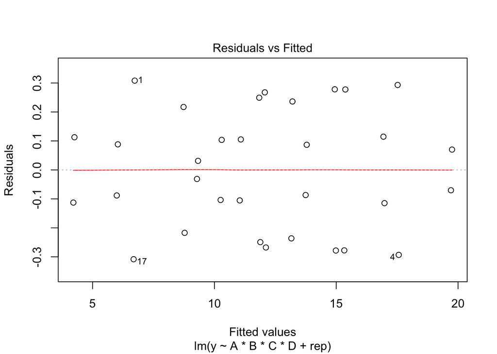

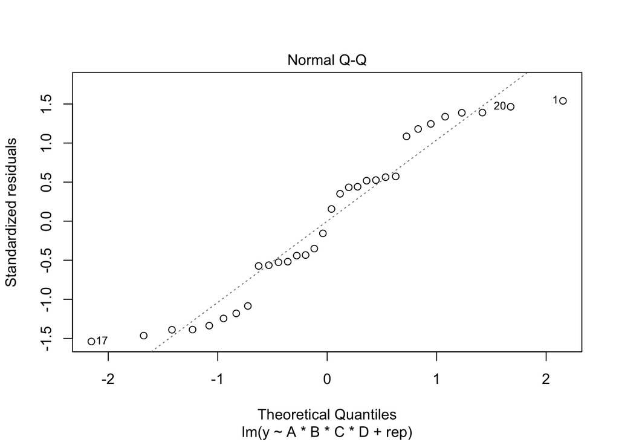

```
## hat values (leverages) are all = 0.53125
##  and there are no factor predictors; no plot no. 5
```

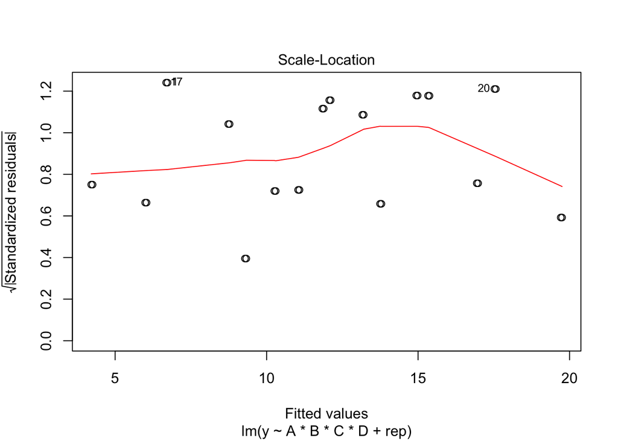

```r
plot(fit1)
```

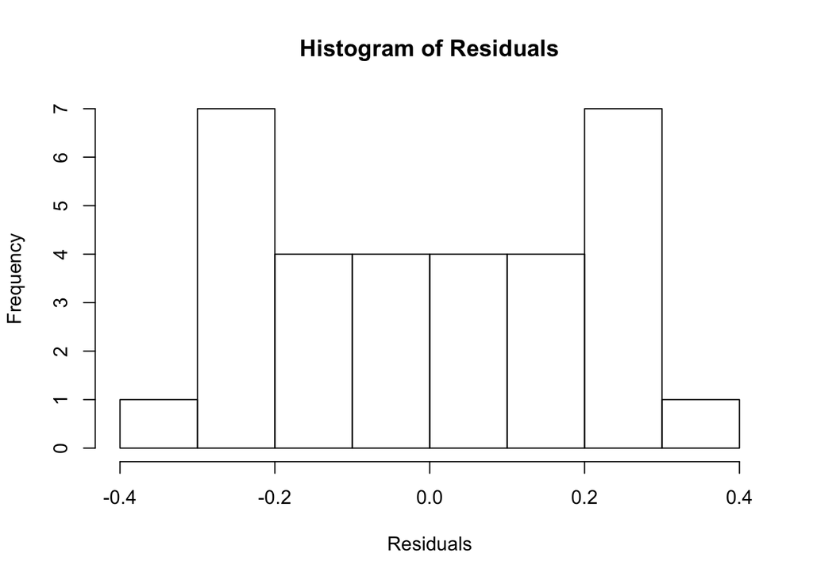

```r
hist(fit1$residuals, xlab = "Residuals", main = "Histogram of Residuals" )
```

I used the plot() function to plot test the residuals. By looking at the Residuals vs Fitted plot, there is no clear pattern in the data points, the distribution is smooth indicating that the variance is constant. However, in analyzing the QQ Plot, there is very clearly some skewing on both ends of the QQ Line. This indicates that the the distribution of the data is *not* Normal. This non-normality was confirmed by the Histogram of the Residuals. Finally, there appear to be a few outliers at points 1, 17, and 20. We could consider removing these outliers from the data as well as using a transformation to correct non-normality of residuals.

## 2. Continuation of Problem 1

### a. (2^4,2) Design

I decided to have ABCD confounded in Replicate I and ABC confounded in Replicate II. Using the methods discussed in lecture, I found the key blocks and “other” blocks for each replicate. The blocks are as follows.

```r
obser.table <- data.frame(R1block1 = c("( 1 )", "ab", "ac", "bc", "ad", "bd", "cd", "abcd"), value1 = c(7.037, 17.273, 4.368, 9.360, 16.867, 13.876, 11.846, 15.653),
                          R1block2 = c("a", "b", "c", "d","abc","abd","acd","bcd"), value2 = c(14.707, 11.635, 10.403, 8.561, 13.440, 19.824, 6.125, 11.190),
                          R2block1 = c("( 1 )", "ab", "ac", "bc", "d", "abd", "acd", "bcd"), value3 = c(6.376, 17.815, 4.098, 9.253, 8.951, 19.639, 5.904, 10.935),
                          R2block2 = c("a", "b", "c", "abc", "ad", "bd", "cd", "abcd"), value4 = c(15.219, 12.089, 10.151, 12.923, 17.052, 13.658, 12.337, 15.053))
kable(obser.table) %>%
        kable_styling(full_width = F, position = "left") %>%
        kable_styling("striped") %>%
        add_header_above(c( "Replicate I ABCD Conf." = 4, "Replicate II ABC Conf." = 4))
```

| Replicate I ABCD Conf. R1block1 | Replicate I ABCD Conf. value1 | Replicate I ABCD Conf. R1block2 | Replicate I ABCD Conf. value2 | Replicate II ABC Conf. R2block1 | Replicate II ABC Conf. value3 | Replicate II ABC Conf. R2block2 | Replicate II ABC Conf. value4 |
| --- | --- | --- | --- | --- | --- | --- | --- |
| ( 1 ) | 7.037 | a | 14.707 | ( 1 ) | 6.376 | a | 15.219 |
| ab | 17.273 | b | 11.635 | ab | 17.815 | b | 12.089 |
| ac | 4.368 | c | 10.403 | ac | 4.098 | c | 10.151 |
| bc | 9.360 | d | 8.561 | bc | 9.253 | abc | 12.923 |
| ad | 16.867 | abc | 13.440 | d | 8.951 | ad | 17.052 |
| bd | 13.876 | abd | 19.824 | abd | 19.639 | bd | 13.658 |
| cd | 11.846 | acd | 6.125 | acd | 5.904 | cd | 12.337 |
| abcd | 15.653 | bcd | 11.190 | bcd | 10.935 | abcd | 15.053 |

The design has 2^1 blocks per replicate and 2^3 treatments per block.

### b. Reconstruction of ANOVA by Sign Table

```r
total_yield = rep.data$Rep_1 + rep.data$Rep_2
total.effect_X = apply(signtable[,-1], 2, function(x) x%*%total_yield)
main.effect_X = round(total.effect_X/2^(k-1)/r,4)
```

For the SS values of ABC and ABCD, we must use only the data from the Replicate that each effect is *not* confounded in. For ABCD, we use replicate 2 to obtain SS. For ABC, we use replicate 1 to obtain SS. We also had to find SS_Block and SS_Block.within.rep. I summed the squared totals for each of the blocks and divided the entire term by 8 as there are 8 treatments per block. To obtain the SS of Blocks from within the Replicates, I subtracted SS_Rep from SS_Block. The following codes show the adjustments made to incorporate the confounding variables.

```r
total.effect_Rep2 = apply(signtable[,-1], 2, function(x) x%*%rep.data$Rep_2)
total.effect_ABCD = -0.169
SS_ABCD = (total.effect_ABCD)^2 / 16
total.effect_Rep1 = apply(signtable[,-1], 2, function(x) x%*%rep.data$Rep_1)
total.effect_ABC = 24.689
SS_ABC = (total.effect_ABC)^2 / 16
SS_X = round((total.effect_X^2/2^k/r),4)
SS_X[15] = SS_ABCD
SS_X[11] = SS_ABC
grand_total = sum(total_yield)
replicate_sum1 <- sum(rep.data$Rep_1)
replicate_sum2 <- sum(rep.data$Rep_2)
SS_Rep = (sum(replicate_sum1^2 + replicate_sum2^2)/rep_size) - (grand_total^2/(2^k*r))
b1_sum <- sum(obser.table$value1)
b2_sum <- sum(obser.table$value2)
b3_sum <- sum(obser.table$value3)
b4_sum <- sum(obser.table$value4)
SS_Block = (sum(b1_sum^2 + b2_sum^2 + b3_sum^2 + b4_sum^2)/8) - (grand_total^2/(2^k*r))
SS_block.within.rep = SS_Block - SS_Rep
SS_total = sum(rep.data$Rep_1^2 + rep.data$Rep_2^2) - (grand_total^2/32)
SS_E = SS_total - (SS_Rep + SS_block.within.rep + sum(SS_X))
pvalue = pf(q = (SS_X/1)/(1.2515/15), df1 = 1, df2 = 15)
ANOVA.manual2 <- data.frame(VarSource = c(names(total.effect_X), "SS_Rep", "SS_Blocks.within.rep", "error", "total"), df = c(rep(1,15),1,2,13,31), SS = c(SS_X, SS_Rep, SS_block.within.rep, SS_E,SS_total)) %>%
        mutate(MS = (SS/df)) %>%
        mutate(F_obs = (MS/(SS_E/13))) %>%
        mutate(Pvalue = pf(F_obs, df1 = 1, df2 = 13, lower.tail = F))
ANOVA.manual2$F_obs[18:19] = NA
ANOVA.manual2$Pvalue[18:19] = NA
ANOVA.manual2$MS[19] = NA
print(ANOVA.manual2, digits = 4)
```

```
##               VarSource df        SS        MS     F_obs    Pvalue
## 1                     A  1 7.291e+01 7.291e+01 7.573e+02 6.563e-13
## 2                     B  1 1.265e+02 1.265e+02 1.314e+03 1.912e-14
## 3                     C  1 1.035e+02 1.035e+02 1.075e+03 6.954e-14
## 4                     D  1 3.066e+01 3.066e+01 3.185e+02 1.591e-10
## 5                    AB  1 2.993e+01 2.993e+01 3.109e+02 1.852e-10
## 6                    AC  1 1.285e+02 1.285e+02 1.335e+03 1.725e-14
## 7                    AD  1 4.680e-02 4.680e-02 4.861e-01 4.979e-01
## 8                    BD  1 1.790e-02 1.790e-02 1.859e-01 6.734e-01
## 9                    BC  1 7.370e-02 7.370e-02 7.655e-01 3.975e-01
## 10                   CD  1 4.730e-02 4.730e-02 4.913e-01 4.957e-01
## 11                  ABC  1 3.810e+01 3.810e+01 3.957e+02 4.065e-11
## 12                  ABD  1 7.680e-02 7.680e-02 7.977e-01 3.880e-01
## 13                  ACD  1 2.900e-03 2.900e-03 3.012e-02 8.649e-01
## 14                  BCD  1 1.020e-02 1.020e-02 1.059e-01 7.500e-01
## 15                 ABCD  1 1.785e-03 1.785e-03 1.854e-02 8.938e-01
## 16               SS_Rep  1 1.584e-02 1.584e-02 1.646e-01 6.916e-01
## 17 SS_Blocks.within.rep  2 4.069e+01 2.034e+01 2.113e+02 2.033e-09
## 18                error 13 1.252e+00 9.627e-02        NA        NA
## 19                total 31 5.722e+02        NA        NA        NA
```

### c. Recontructed ANOVA by R

I again used the data.frame() function to fit a dataframe with blocks added this time. I fit a second model and constructed the ANOVA table for the model.

```r
treat.combi <- data.frame(A = c(-1, 1, -1, 1, -1, 1, -1, 1,
                 -1, 1, -1, 1, -1, 1, -1, 1), B = c(-1, -1, 1, 1, -1, -1, 1, 1,
                 -1, -1, 1, 1, -1, -1, 1, 1), C = c(-1, -1, -1, -1, 1, 1, 1, 1,
                 -1, -1, -1, -1, 1, 1, 1, 1), D = c(-1, -1, -1, -1, -1, -1, -1, -1,
                 1, 1, 1, 1, 1, 1, 1, 1))
treat.combi$design <- design
rep.12 <- data.frame(treat.combi, y = c(7.037,14.707,11.635,17.273,10.403,4.368,9.360,13.440,8.561,16.867,13.876,19.824,11.846,6.125,11.190,15.653))
rep.22 <- data.frame(treat.combi, y = c(6.376,15.219,12.089,17.815,10.151,4.098,9.253,12.923,8.951,17.052,13.658,19.639,12.337,5.904,10.935,15.053))
rep.bind2 = rbind(rep.12,rep.22)
block = c(1,2,2,1,2,1,1,2,2,1,1,2,1,2,2,1,3,4,4,3,4,3,3,4,3,4,4,3,4,3,3,4)
data.all3 <- data.frame(rep.bind2, rep = rep(c(1,2), each = 16), block)
fit2 <- lm(y ~ A*B*C*D + rep + factor(block), data = data.all3)
anova(fit2)
```

```
## Analysis of Variance Table
##
## Response: y
##               Df  Sum Sq Mean Sq   F value    Pr(>F)
## A              1  72.909  72.909  757.2486 6.567e-13 ***
## B              1 126.461 126.461 1313.4504 1.913e-14 ***
## C              1 103.464 103.464 1074.6028 6.958e-14 ***
## D              1  30.662  30.662  318.4657 1.592e-10 ***
## rep            1   0.016   0.016    0.1645    0.6916
## factor(block)  2  40.685  20.343  211.2843 1.221e-10 ***
## A:B            1  29.927  29.927  310.8260 1.853e-10 ***
## A:C            1 128.496 128.496 1334.5949 1.726e-14 ***
## B:C            1   0.074   0.074    0.7658    0.3974
## A:D            1   0.047   0.047    0.4863    0.4979
## B:D            1   0.018   0.018    0.1855    0.6737
## C:D            1   0.047   0.047    0.4910    0.4958
## A:B:C          1  38.097  38.097  395.6811 4.068e-11 ***
## A:B:D          1   0.077   0.077    0.7980    0.3879
## A:C:D          1   0.003   0.003    0.0304    0.8643
## B:C:D          1   0.010   0.010    0.1055    0.7505
## A:B:C:D        1   0.002   0.002    0.0185    0.8938
## Residuals     13   1.252   0.096
## ---
## Signif. codes:  0 '***' 0.001 '**' 0.01 '*' 0.05 '.' 0.1 ' ' 1
```